# Grammar of graphics

Mahbubul Majumder, PhD  
Feb 9, 2017

### What is grammar of graphics

- describes the deep features that underlie all statistical graphics
- an answer to a question: what is a statistical graphic?
- according to Hadley Wickham

  The grammar tells us that a statistical graphic is a mapping from data to aesthetic attributes (colour, shape, size) of geometric objects (points, lines, bars).

### Why do we need a grammar of graphics

- similar to asking why we need a grammar
  - the fundamental principles or rules of an art or science
- consistency of plots
- it allows
  - extension of a graphics without changing much
  - switch between geometries of the plot without complexity
  - complex graphics to be generated in less effort
  - restrictions to make common mistakes
  - easy reproducibility

### Case Study: Engine displacement

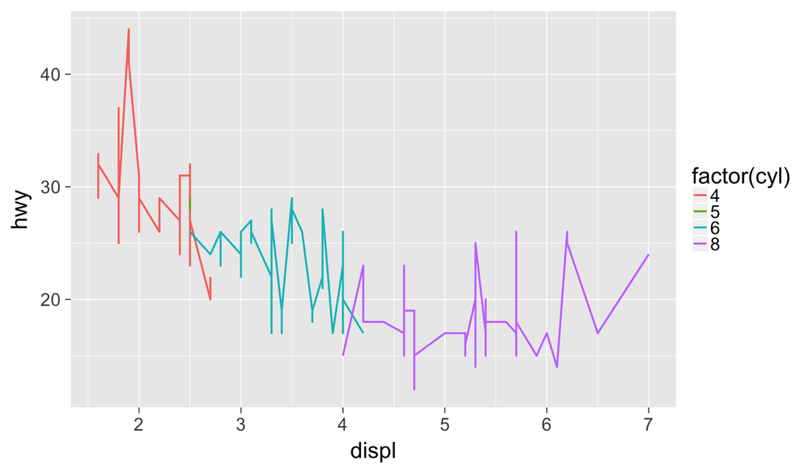

```r
ggplot(mpg, aes(displ, hwy, colour = factor(cyl))) +
  geom_line(size=1)
```

### Case Study: Engine displacement

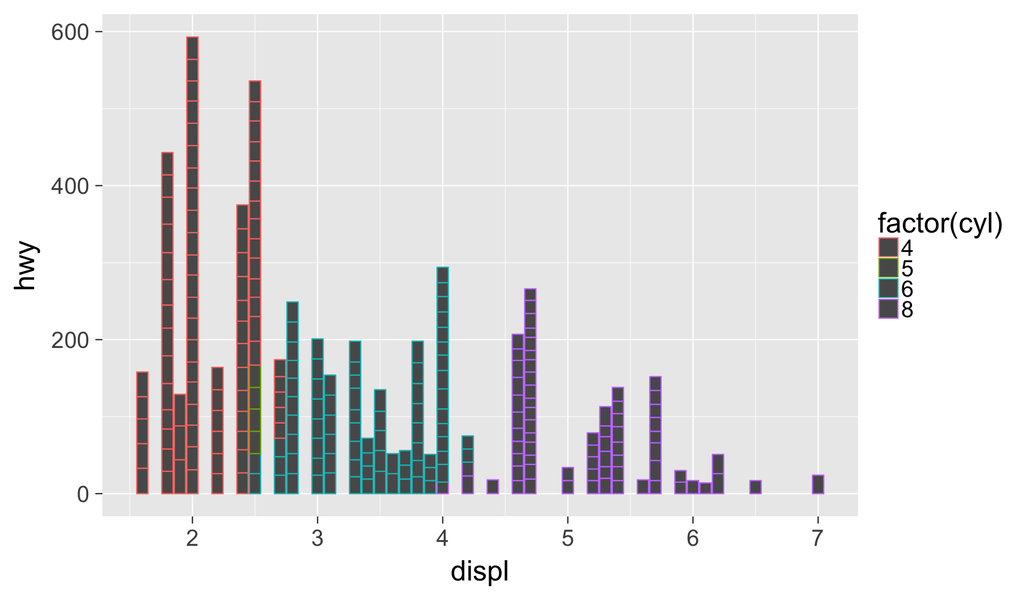

```r
ggplot(mpg, aes(displ, hwy, colour = factor(cyl))) +
  geom_bar(stat="identity")
```

### Case Study: Engine displacement

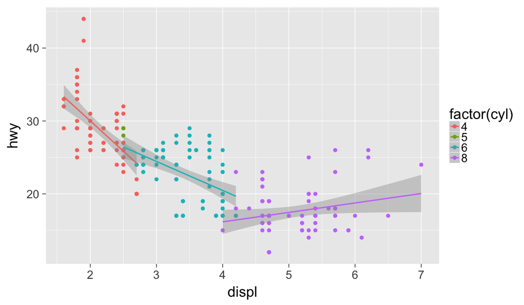

```r
ggplot(mpg, aes(displ, hwy, colour = factor(cyl))) +
  geom_point(size=2.5) +
  geom_smooth(method = "lm")
```

### Reading assignment and references

- [The Grammar of Graphics](http://books.google.com/books/about/The_Grammar_of_Graphics.html?id=_kRX4LoFfGQC), by Leland Wilkinson.
- [A Layered Grammar of Graphics](http://byrneslab.net/classes/biol607/readings/wickham_layered-grammar.pdf) by Hadley Wickham.
- [ggplot2](http://www.springer.com/statistics/computational+statistics/book/978-0-387-98140-6), Elegant Graphics for Data Analysis by Hadley Wickham.
- [ggplot2, an Implimentation of Grammar of Graphics](http://ggplot2.org/resources/2007-vanderbilt.pdf) a talk given by Hadley Wickham at Vanderbilt University.
- `ggplot2` web site with nice documentation  
  http://docs.ggplot2.org/current/